# NLP project on MU3D

Kun Bu

2022-11-14

# Introduction

This NLP project focus on the same data set MU3D, which has a column fracture called “Transcription”. The Transcription contains the Full transcription of the video, which is a text record of the video for each volunteer. My goal in this NLP part is to calculate the text TF-IDF, which is Term Frequency-Inverse Document Frequency, to define the importance of a keyword or phrase within a document. TF- IDF is the product of two statistics, term frequency and inverse document frequency. where the equations are:

$$\begin{align*}
TF: \quad tf(t,d) = \frac{f_{(t,d)}}{\sum_{{t^{'} \in
d}}f_{t^{'}, d}} \\
\newline
IDF: \quad idf(t, D) = \log\frac{N}{|\{d \in D: t \in d\}|}\\
\newline
TF-IDF: \quad tfidf(t, d, D) = tf(t,d) \cdot idf(t, D)
\end{align*}$$

To interpret the value of TF-IDF, the higher the TF-IDF score the more important or relevant the term is; as a term gets less relevant, its TF-IDF score will approach 0.

Next, I will import the dataset and calculate the TF-IDF and interpret it step by step.

# Input Data

```r
library(dplyr)
library(janeaustenr)
library(tidytext)
data <- read.csv("MU3D_Video_Level_Data.csv")
```

# Data cleaning

```r
data$Transcription <- gsub('[[:punct:] ]+',';',data$Transcription)
data$Labels <- ifelse(grepl("T", data$VideoID)=="TRUE", "T", "L")
data2 <- data %>% unnest_tokens(words,Transcription,token = stringr::str_split, pattern = ";") %>%
  select(VideoID, words, Labels)
```

# Calculate TF-IDF

```r
cluster_words <- data2 %>%
  count(Labels,words,sort = TRUE)
cluster_total_words <- cluster_words %>%
  group_by(Labels) %>%
  summarize(total=sum(n))
cluster_words <- left_join(cluster_words,cluster_total_words)
cluster_words <- cluster_words %>%
  arrange(Labels)
```

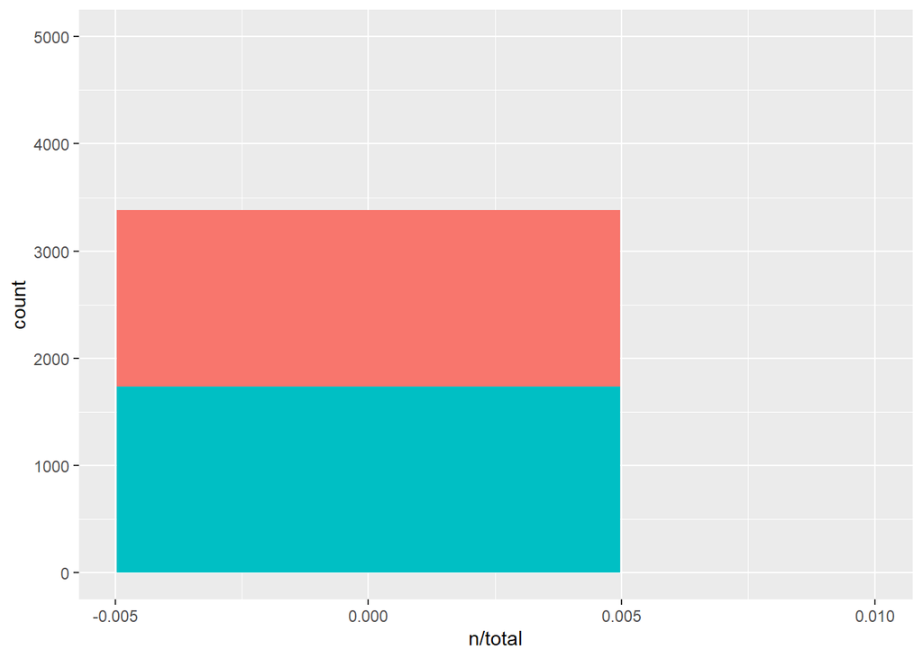

```r
library(ggplot2)
ggplot(cluster_words, aes(n/total, fill = Labels)) +
  geom_histogram(show.legend = FALSE,bins = 2) +
  xlim(NA, 0.01) +
  coord_cartesian(ylim=c(0,5000))
```

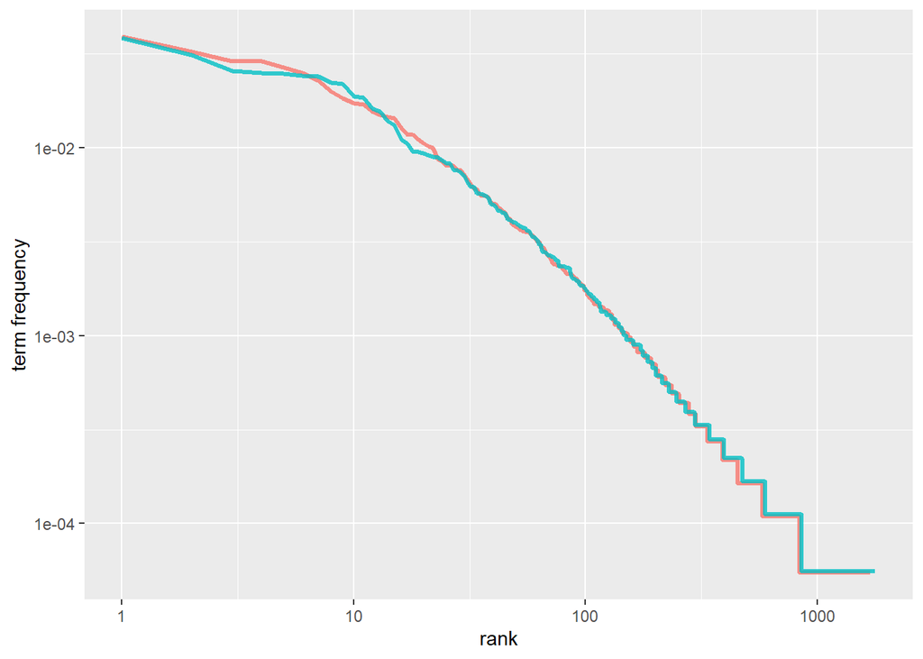

```r
freq_by_rank <- cluster_words %>%
  group_by(Labels) %>%
  mutate(rank = row_number(),
         `term frequency` = n/total) %>%
  ungroup()


freq_by_rank %>%
  ggplot(aes(rank, `term frequency`, color = Labels)) +
  geom_line(size = 1.1, alpha = 0.8, show.legend = FALSE) +
  scale_x_log10() +
  scale_y_log10()
```

```r
cluster_tf_idf <- cluster_words %>%
  bind_tf_idf(words, Labels, n)
cluster_tf_idf
```

```
##      Labels             words   n total           tf       idf       tf_idf
## 1         L               and 717 18321 3.913542e-02 0.0000000 0.000000e+00
## 2         L                 i 598 18321 3.264014e-02 0.0000000 0.000000e+00
## 3         L               she 532 18321 2.903772e-02 0.0000000 0.000000e+00
## 4         L                 s 529 18321 2.887397e-02 0.0000000 0.000000e+00
## 5         L                he 491 18321 2.679985e-02 0.0000000 0.000000e+00
## 6         L                to 459 18321 2.505322e-02 0.0000000 0.000000e+00
## 7         L              like 418 18321 2.281535e-02 0.0000000 0.000000e+00
## 8         L                um 366 18321 1.997708e-02 0.0000000 0.000000e+00
## 9         L                 a 338 18321 1.844877e-02 0.0000000 0.000000e+00
## 10        L               the 317 18321 1.730255e-02 0.0000000 0.000000e+00
## 11        L            really 311 18321 1.697506e-02 0.0000000 0.000000e+00
## 12        L                of 288 18321 1.571967e-02 0.0000000 0.000000e+00
## 13        L                we 275 18321 1.501010e-02 0.0000000 0.000000e+00
## 14        L              that 268 18321 1.462802e-02 0.0000000 0.000000e+00
```

[output cut: 3450 more lines]

# Justisfication

As the above result shows the words, for example, “and”, “I”, “you” “to”, “a”, “the”, etc, has a value of zero TF-IDF, which means those words are the least important in the transcription. In the later work, I can remove those words to avoid expensive computational time and increase the accuracy of machine learning classification.